# Supplementary materials for EBI-ADHD

Gosling CJ, Garcia-Argibay M, […], Ioannidis J, Radua J, Solmi M, Delorme R & Cortese S, and the EBI-ADHD team

2025-05-11

# S1. PRIOR checklist

All of the key stages of the umbrella review (screening, data extraction, and assessment of quality were performed by two independent reviewers/investigators), and double-checked by first authors/investigators leading the project. Disagreements were resolved by the senior authors.

[output not shown]

# S2. Deviations

# S3. Search strategies

The search can be retrieved in our [protocol](https://osf.io/fr27k)

[figure not shown]

# S4. Overlapping meta-analyses

The exact selection procedure can be retrieved in our [protocol](https://osf.io/fr27k)

## Primary Analysis: Intervention vs Inactive Control Comparisons

There may likely be PWMAs/NMAs/IPD-MA focusing on the same PICO. In this case, a 4-level selection will be progressively implemented.

### First-Level Selection: Replicable work

We will retain only meta-analyses that provide complete data needed for replication, including effect sizes, variances or 95% confidence intervals, and sample sizes. This transparency will allow us to verify the original authors’ calculations and apply a standardized framework for evidence stratification.

### Second-Level Selection: Recent Publications

PWMA/NMA/IPD-MA published after January 1st, 2018 will be considered with priority. This criterion will allow us to avoid outdated and hence likely less comprehensive PWMA/NMA/IPD-MA.

### Third-Level Selection: Age Group Homogeneity

Among recent PWMA/NMAs/IPD-MA, only those analyzing homogeneous age groups will be retained, as treatment effects vary across sage groups.

### Fourth-Level Selection: Methodological Quality

When multiple PWMA/NMAs/IPD-MA meet the above criteria, we will select the one with the highest methodological quality, assessed using five key AMSTAR criteria:

1. Protocol pre-registration
2. Comprehensive search strategy
3. Duplicate study selection
4. Duplicate data extraction
5. Risk of bias assessment

If several PWMA/NMAs/IPD-MA published after January 1st 2018, with homogeneous age groups, and identical methodological quality are available, we will favor the NMA over the PWMA and IPD-MA.

### Alternative Selection Paths

If no PWMA/NMA published after 2018 meet the primary criteria, the following hierarchical approach will be used:

1. Pre-2018 meta-analyses with homogeneous age groups
2. For cases where no PWMA/NMA/IPD-MA with homogeneous age groups exist (regardless of publication date), selection will be based on methodological quality, with separate analyses conducted for the different age groups.

# S5. Incl./Excl. criteria

The exact criteria can be retrieved in our [protocol](https://osf.io/fr27k). All inclusion criteria pertaining to the PICO were applied at the RCT level. As a result, when a meta-analysis included both eligible and ineligible trials, we retained the meta-analysis but excluded the trials that did not meet our criteria.

## Population

All meta-analytic reports had to pool at least two RCTs including participants with standardized ADHD diagnoses, i.e., those based on formal criteria of the Diagnostic and Statistical Manual of Mental Disorders (DSM, versions from III to 5-TR) or the International Classification of Diseases (versions 9–11) assessed by a trained clinician, such as a psychologist or a psychiatrist. Meta-analyses including RCTs relying exclusively on inappropriate diagnostic procedures (such as scores above cut-off on questionnaires, or self-report diagnoses) were ineligible. Additionally, meta-analyses that combined data from participants diagnosed with both standards and inappropriate procedures were eligible only if the data were presented in a way enabling to remove studies with inappropriate procedures.

[figure not shown]

## Interventions

The exact criteria can be retrieved in our [protocol](https://osf.io/fr27k).

We did not exclude any specific intervention type, but, to ensure methodologically accurate results, we excluded some meta-analyses that could lead to biased conclusions.

1. We did not include meta-analyses that pooled heterogeneous interventions, such as combining distinct treatments (for instance CBT, parent training, and behavioral therapies under a broad label such as “psychosocial treatments”, or methylphenidate and amphetamines under the broad label of “stimulants”). This aggregation could mask the individual effects of each intervention, which are conceptually and practically different.
2. By contrast, we retained meta-analyses including RCTs testing combined interventions evaluated against one of the active components (e.g., methylphenidate + CBT vs. methylphenidate). However, because, in the retained meta-analyses, trials using this “A+B versus B” design were often included alongside trials comparing interventions to controls (e.g., placebo, waitlist, or treatment as usual), we did not analyse separately those meta-analyses of RCTs focusing exclusively on trials with an “A+B versus B” design, as this would have led to redundancy in the dataset.
3. More broadly, we included meta-analyses containing RCTs that permitted participants to continue stable baseline interventions (for example, RCTs where 80% of randomised participants maintained their pre-existing stabilised medications). This inclusion criterion enhances the real-world applicability of our findings. Unfortunately, this baseline intervention variable was inconsistently reported across meta-analyses, limiting our ability to conduct subgroup analyses. Specifically, we could not reliably perform meta-regression analyses to compare effect estimates from RCTs testing interventions as monotherapy versus those testing the same interventions as augmentation to existing treatments.

A description of all included interventions is available [online](https://ebiadhd-database.org/interventions/).

```r
sort(unique(res_m$Intervention))
```

```
##  [1] "Acupuncture"
##  [2] "Alpha-2 agonists (guanfacine / clonidine)"
##  [3] "Amphetamines"
##  [4] "Atomoxetine"
##  [5] "Bupropion"
##  [6] "Carnitine"
##  [7] "Centafanadine"
##  [8] "Cognitive Behavioral Therapy (CBT)"
##  [9] "Cognitive training"
## [10] "Dasotraline"
## [11] "Desipramine"
## [12] "Dialectical Behavioral Therapy (DBT)"
## [13] "Diet (restricted/elimination)"
## [14] "Homeopathy"
## [15] "Methylphenidate"
```

[output cut: 17 more lines]

[figure not shown]

## Comparators

The exact criteria can be retrieved in our [protocol](https://osf.io/fr27k).

[figure not shown]

## Outcomes

The exact criteria can be retrieved in our [protocol](https://osf.io/fr27k).

```r
sort(unique(res_m$Outcome))
```

```
##  [1] "Academic/job performance"
##  [2] "Acceptability"
##  [3] "AE (decreased appetite)"
##  [4] "AE (sleep problems)"
##  [5] "CD/ODD symptoms"
##  [6] "CGI"
##  [7] "Conduct disorder symptoms (CD)"
##  [8] "Core ADHD symptoms [Clinician-rated]"
##  [9] "Core ADHD symptoms [Mixed]"
## [10] "Core ADHD symptoms [Parent-rated]"
## [11] "Core ADHD symptoms [Self-rated]"
## [12] "Core ADHD symptoms [Teacher-rated]"
## [13] "Depressive disorder symptoms"
## [14] "Disruptive behaviors"
## [15] "Driving"
## [16] "Emotional dysregulation"
## [17] "Exec. functions (mixed)"
## [18] "Exec. functions (report)"
## [19] "Exec. functions (tests)"
## [20] "Generalized anxiety"
## [21] "Learning disorder symptoms"
## [22] "Oppositional symptoms (ODD)"
## [23] "Quality of life"
## [24] "Social-communication skills"
## [25] "Suicidal ideation/behavior"
## [26] "Tics/Tourette disorder symptoms"
## [27] "Tolerability"
```

[figure not shown]

# S6. GRADE criteria

### Risk of Bias (Limitations)

- **No downgrade**: >=75% of participants included in low-risk studies
- **One downgrade**: 50%-75% of participants included in low-risk studies
- **Two downgrades**: <=50% of participants included in low-risk studies

The pooled percentage of participants is calculated as a weighted mean, with weights attributed to each study being equal to the weight each study receives in the meta-analysis.

We considered a study to be at low risk of bias when there were no high risk of ‘randomization’, ‘outcome measurement’ or ‘reporting bias’.

### Heterogeneity

- **Two downgrades**: Substantial discrepancy between the 95% CI and 95% PI (e.g., bounds of the 95% CI and 95% PI not of the same sign and in different equivalence ranges).
- **One downgrade**: Small/moderate discrepancy between the 95% CI and 95% PI (e.g., bounds of the 95% CI and 95% PI of the same sign, but in different equivalence ranges).

When 95% PI is not reliably estimable, the assessment relies on the I² statistic and the percentage of studies with contradicting results:

- **Two downgrades**: I² >= 50% and >=10% of studies with statistically significant results in the opposite direction compared to the pooled effect size
- **One downgrade**: I² >= 30% and >=10% of studies with statistically significant results in the opposite direction compared to the pooled effect size

### Indirectness

The number of downgrades and the criteria are left to the user’s discretion, as these factors vary significantly depending on the scope of the review. Examples of criteria may include heterogeneity in participants’ age or undefined control groups:

- **No downgrade**: No concerns regarding indirectness
- **One downgrade**: Serious concerns (e.g., “serious” indirectness)
- **Two downgrades**: Very serious concerns (e.g., “very serious” indirectness)

### Imprecision

- **Two downgrades**: The 95% CI of the pooled effect size includes both null (SMD = 0; RR/OR = 1) and large (SMD >= 0.80; OR/RR >= 5) effects AND the meta-analysis does not have the sample size required to detect small effects (eSMD = 0.20) with 80% statistical power (n < 394 per arm)
- **One downgrade**: The 95% CI of the pooled effect size includes both null and large effects
- **Two downgrades**: The meta-analysis does not have the sample size required to detect moderate effects (eSMD = 0.50) with 80% statistical power (n < 64 per arm)
- **One downgrade**: The meta-analysis does not have the sample size required to detect small effects (eSMD = 0.20) with 80% statistical power (n < 394 per arm)

### Publication Bias

- **One downgrade**: p-value of Egger’s test < 0.10, OR excess significance bias p-value < 0.10, OR more than 50% of participants included in trials with high reporting bias

# S7 Data analytic strategy

All analyses were performed in the R environment (version 4.1.1) using the ‘metaumbrella’ package. We used the standardized mean difference (SMD) as the main effect size measure for the assessment of efficacy and Risk Ratio (RR) for the assessment of safety measures (i.e., acceptability, tolerability, and adverse events).

We re-ran all meta-analyses comparing intervention and control groups using random-effects models. To estimate between-study heterogeneity variance (τ²), we employed restricted maximum likelihood (REML) estimators for SMD and Paul-Mandel estimators for OR or RR. Pooled effect sizes were reported with 95% confidence intervals derived from the standard normal quantile (Wald) method. Heterogeneity was assessed using I² statistics, Q-statistics, τ² values, and 95% prediction intervals. To evaluate small-study effects, we applied Egger’s regression asymmetry test, analyzed excess statistical significance bias, and quantified the proportion of participants in studies with high risk of selective reporting bias. Where meta-analyses included dependent effect sizes, we resolved dependency using the standardized data aggregation method proposed by Borenstein and colleagues.

# S8. Included studies

| id | cite |
| --- | --- |
| 93 | Ang, L., et al., Acupuncture for Treating Attention Deficit Hyperactivity Disorder in Children: A Systematic Review and Meta-Analysis. Medicina (Kaunas), 2023. 59(2). |
| 153 | Arns, M., et al., Efficacy of neurofeedback treatment in ADHD: the effects on inattention, impulsivity and hyperactivity: a meta-analysis. Clin EEG Neurosci, 2009. 40(3): p. 180-9. |
| 185 | Auclair, V., P.O. Harvey, and M. Lepage, [Cognitive Behavioral Therapy and the Treatment of ADHD in Adults]. Sante Ment Que, 2016. 41(1): p. 291-311. |
| 296 | Bemanalizadeh, M., M. Yazdi, O. Yaghini, and R. Kelishadi, A meta-analysis on the effect of telemedicine on the management of attention deficit and hyperactivity disorder in children and adolescents. … |
| 343 | Bikic, A., et al., Meta-analysis of organizational skills interventions for children and adolescents with Attention-Deficit/Hyperactivity Disorder. Clin Psychol Rev, 2017. 52: p. 108-123. |
| 371 | Bloch, M.H., K.E. Panza, A. Landeros-Weisenberger, and J.F. Leckman, Meta-analysis: treatment of attention-deficit/hyperactivity disorder in children with comorbid tic disorders. J Am Acad Child Adole… |
| 381 | Boesen, K., A.S. Paludan-Müller, P.C. Gøtzsche, and K.J. Jørgensen, Extended-release methylphenidate for attention deficit hyperactivity disorder (ADHD) in adults. Cochrane Database Syst Rev, 2022. 2(… |
| 474 | Bryant, A., et al., A meta-analytic review of the impact of ADHD medications on anxiety and depression in children and adolescents. Eur Child Adolesc Psychiatry, 2023. 32(10): p. 1885-1898. |
| 501 | Bushe, C., et al., A network meta-analysis of atomoxetine and osmotic release oral system methylphenidate in the treatment of attention-deficit/hyperactivity disorder in adult patients. J Psychopharma… |
| 505 | Bussalb, A., et al., Clinical and Experimental Factors Influencing the Efficacy of Neurofeedback in ADHD: A Meta-Analysis. Front Psychiatry, 2019. 10: p. 35. |
| 529 | Cândido, R.C.F., C.A. Menezes de Padua, S. Golder, and D.R. Junqueira, Immediate-release methylphenidate for attention deficit hyperactivity disorder (ADHD) in adults. Cochrane Database Syst Rev, 2021… |
| 563 | Castells, X., L. Blanco-Silvente, and R. Cunill, Amphetamines for attention deficit hyperactivity disorder (ADHD) in adults. Cochrane Database Syst Rev, 2018. 8(8): p. Cd007813. |
| 565 | Castells, X., R. Cunill, and D. Capellà, Treatment discontinuation with methylphenidate in adults with attention deficit hyperactivity disorder: a meta-analysis of randomized clinical trials. Eur J Cl… |
| 571 | Castells, X., et al., Efficacy of methylphenidate for adults with attention-deficit hyperactivity disorder: a meta-regression analysis. CNS Drugs, 2011. 25(2): p. 157-69. |
| 575 | Catalá-López, F., et al., The pharmacological and non-pharmacological treatment of attention deficit hyperactivity disorder in children and adolescents: A systematic review with network meta-analyses … |
| 589 | Cerrillo-Urbina, A.J., et al., The Effects of Long-Acting Stimulant and Nonstimulant Medications in Children and Adolescents with Attention-Deficit/Hyperactivity Disorder: A Meta-Analysis of Randomize… |
| 590 | Cerrillo-Urbina, A.J., et al., The effects of physical exercise in children with attention deficit hyperactivity disorder: a systematic review and meta-analysis of randomized control trials. Child Car… |
| 600 | Chang, J.P., K.P. Su, V. Mondelli, and C.M. Pariante, Omega-3 Polyunsaturated Fatty Acids in Youths with Attention Deficit Hyperactivity Disorder: a Systematic Review and Meta-Analysis of Clinical Tri… |
| 626 | Chen, J.W. and K. Zhu, Single Exercise for Core Symptoms and Executive Functions in ADHD: A Systematic Review and Meta-Analysis. J Atten Disord, 2023: p. 10870547231217321. |
| 633 | Chen, S., et al., Which Factor Is More Relevant to the Effectiveness of the Cognitive Intervention? A Meta-Analysis of Randomized Controlled Trials of Cognitive Training on Symptoms and Executive Func… |
| 638 | Chen, Y.H., et al., A meta-analysis on the therapeutic efficacy of repetitive transcranial magnetic stimulation for cognitive functions in attention-deficit/hyperactivity disorders. BMC Psychiatry, 20… |
| 658 | Ching, C., G.D. Eslick, and A.S. Poulton, Evaluation of Methylphenidate Safety and Maximum-Dose Titration Rationale in Attention-Deficit/Hyperactivity Disorder: A Meta-analysis. JAMA Pediatr, 2019. 17… |
| 662 | Chiu, H.J., et al., Efficacy and tolerability of psychostimulants for symptoms of attention-deficit hyperactivity disorder in preschool children: A systematic review and meta-analysis. Eur Psychiatry,… |
| 676 | Chung, W., et al., Factors influencing therapeutic effectiveness of electroencephalogram-based neurofeedback against core symptoms of ADHD: a systematic review and meta-analysis. Journal of Psychiatry… |
| 701 | Coates, J., J.A. Taylor, and K. Sayal, Parenting Interventions for ADHD: A Systematic Literature Review and Meta-Analysis. J Atten Disord, 2015. 19(10): p. 831-43. |
| 711 | Coghill, D.R., et al., Effects of methylphenidate on cognitive functions in children and adolescents with attention-deficit/hyperactivity disorder: evidence from a systematic review and a meta-analysi… |
| 757 | Cortese, S., et al., Comparative efficacy and tolerability of medications for attention-deficit hyperactivity disorder in children, adolescents, and adults: a systematic review and network meta-analys… |
| 772 | Cortese, S., et al., Cognitive training for attention-deficit/hyperactivity disorder: meta-analysis of clinical and neuropsychological outcomes from randomized controlled trials. J Am Acad Child Adole… |
| 798 | Coulter, M.K. and M.E. Dean, Homeopathy for attention deficit/hyperactivity disorder or hyperkinetic disorder. Cochrane Database Syst Rev, 2007(4): p. Cd005648. |
| 817 | Cunill, R., X. Castells, A. Tobias, and D. Capellà, Atomoxetine for attention deficit hyperactivity disorder in the adulthood: a meta-analysis and meta-regression. Pharmacoepidemiol Drug Saf, 2013. 22… |

[output cut: 85 more lines]

# S9. Excluded studies

| id | cite | reason | n |
| --- | --- | --- | --- |
| 222 | Baird, D. and A. Hoffman, Use of amphetamines for attention-deficit/hyperactivity disorder in adults. American Family Physician, 2019. 100(5): p. 278-279. | Unclear ADHD diagnosis | 137 |
| 266 | Battagliese, G., et al., Cognitive-behavioral therapy for externalizing disorders: A meta-analysis of treatment effectiveness. Behav Res Ther, 2015. 75: p. 60-71. | Unclear ADHD diagnosis | 137 |
| 470 | Bruton, A., et al., Phosphatidylserine for the treatment of pediatric attention-deficit/hyperactivity disorder: A systematic review and meta-analysis. Global Advances in Health and Medicine, 2020. Con… | Unclear ADHD diagnosis | 137 |
| 471 | Bruton, A., et al., Phosphatidylserine for the Treatment of Pediatric Attention-Deficit/Hyperactivity Disorder: A Systematic Review and Meta-Analysis. J Altern Complement Med, 2021. 27(4): p. 312-322. | Unclear ADHD diagnosis | 137 |
| 506 | Bustamante, E.E., et al., Diverse multi-week physical activity programs reduce ADHD symptoms: A systematic review and meta-analysis. Psychology of Sport and Exercise, 2022. 63: p. 102268. | Unclear ADHD diagnosis | 137 |
| 507 | Bustamante, E.E., et al., Diverse Multi-Week Physical Activity Programs Reduce ADHD Symptoms: A Meta-Analysis. Medicine & Science in Sports & Exercise, 2022. 54(9): p. 51-52. | Unclear ADHD diagnosis | 137 |
| 607 | Charach, A., et al., Interventions for preschool children at high risk for ADHD: a comparative effectiveness review. Pediatrics, 2013. 131(5): p. e1584-604. | Unclear ADHD diagnosis | 137 |
| 642 | Cheng, J.Y., R.Y. Chen, J.S. Ko, and E.M. Ng, Efficacy and safety of atomoxetine for attention-deficit/hyperactivity disorder in children and adolescents-meta-analysis and meta-regression analysis. Ps… | Unclear ADHD diagnosis | 137 |
| 653 | Chierrito de Oliveira, D., et al., Safety of Treatments for ADHD in Adults: Pairwise and Network Meta-Analyses. J Atten Disord, 2019. 23(2): p. 111-120. | Unclear ADHD diagnosis | 137 |
| 657 | Chimiklis, A.L., et al., Yoga, Mindfulness, and Meditation Interventions for Youth with ADHD: Systematic Review and Meta-Analysis. Journal of Child and Family Studies, 2018. 27(10): p. 3155-3168. | Unclear ADHD diagnosis | 137 |
| 675 | Chueh, T.Y., et al., Effects of a single bout of moderate-to-vigorous physical activity on executive functions in children with attention-deficit/hyperactivity disorder: A systematic review and meta-a… | Unclear ADHD diagnosis | 137 |
| 723 | Connor, D.F., K.E. Fletcher, and J.M. Swanson, A meta-analysis of clonidine for symptoms of attention-deficit hyperactivity disorder. J Am Acad Child Adolesc Psychiatry, 1999. 38(12): p. 1551-9. | Unclear ADHD diagnosis | 137 |
| 734 | Cooper, R.E., et al., The effect of omega-3 polyunsaturated fatty acid supplementation on emotional dysregulation, oppositional behaviour and conduct problems in ADHD: A systematic review and meta-ana… | Unclear ADHD diagnosis | 137 |
| 736 | Corcoran, J. and P. Dattalo, Parent involvement in treatment for ADHD: A meta-analysis of the published studies. Research on Social Work Practice, 2006. 16(6): p. 561-570. | Unclear ADHD diagnosis | 137 |
| 739 | Cordier, R., et al., Friendship interventions for children with neurodevelopmental needs: A systematic review and meta-analysis. PLoS One, 2023. 18(12): p. e0295917. | Unclear ADHD diagnosis | 137 |
| 740 | Cordier, R., et al., Peer Inclusion in Interventions for Children with ADHD: A Systematic Review and Meta-Analysis. Biomed Res Int, 2018. 2018: p. 7693479. | Unclear ADHD diagnosis | 137 |
| 748 | Corrigan, N., C.R. Păsărelu, and A. Voinescu, Immersive virtual reality for improving cognitive deficits in children with ADHD: a systematic review and meta-analysis. Virtual Real, 2023: p. 1-20. | Unclear ADHD diagnosis | 137 |
| 774 | Cortese, S., et al., Neurofeedback for Attention-Deficit/Hyperactivity Disorder: Meta-Analysis of Clinical and Neuropsychological Outcomes From Randomized Controlled Trials. J Am Acad Child Adolesc Ps… | Unclear ADHD diagnosis | 137 |
| 871 | De Crescenzo, F., et al., The use of actigraphy in the monitoring of methylphenidate versus placebo in ADHD: a meta-analysis. Atten Defic Hyperact Disord, 2014. 6(1): p. 49-58. | Unclear ADHD diagnosis | 137 |
| 885 | de Oliveira, F.N., et al., Use of Bach flower remedies in children and adolescents with attention deficit hyperactivity disorder: Systematic review and meta-analysis. Advances in Integrative Medicine.… | Unclear ADHD diagnosis | 137 |
| 905 | Dekkers, T.J., et al., Meta-analysis: Which Components of Parent Training Work for Children With Attention-Deficit/Hyperactivity Disorder? J Am Acad Child Adolesc Psychiatry, 2022. 61(4): p. 478-494. | Unclear ADHD diagnosis | 137 |
| 1020 | DuPaul, G.J. and T.L. Eckert, The effects of school-based interventions for Attention Deficit Hyperactivity Disorder: A meta-analysis. School Psychology Review, 1997. 26(1): p. 5-27. | Unclear ADHD diagnosis | 137 |
| 1021 | DuPaul, G.J., T.L. Eckert, and B. Vilardo, The effects of school-based interventions for attention deficit hyperactivity disorder: A meta-analysis 1996-2010. School Psychology Review, 2012. 41(4): p. … | Unclear ADHD diagnosis | 137 |
| 1052 | Elbe, P., et al., Computerized cognitive interventions for adults with ADHD: A systematic review and meta-analysis. Neuropsychology, 2023. 37(5): p. 519-530. | Unclear ADHD diagnosis | 137 |
| 1081 | Fabiano, G.A., et al., A meta-analysis of behavioral treatments for attention-deficit/hyperactivity disorder. Clin Psychol Rev, 2009. 29(2): p. 129-40. | Unclear ADHD diagnosis | 137 |
| 1084 | Fabiano, G.A., et al., Comprehensive meta-analysis of attention-deficit/hyperactivity disorder psychosocial treatments investigated within between group studies. Review of Educational Research, 2021. … | Unclear ADHD diagnosis | 137 |
| 1089 | Falone, A., et al., Homeopathic remedies in psychiatric disorders: A metaanalysis of randomized controlled trials. European Psychiatry, 2020. 63(Supplement 1): p. S145-S146. | Unclear ADHD diagnosis | 137 |
| 1129 | Farcas, S., I. Szamosközi, and Á. Takács, The effects of working memory trainings with game elements for children with ADHD A meta-analytic review. Erdélyi Pszichológiai Szemle, 2016. 17(1): p. 21-44. | Unclear ADHD diagnosis | 137 |
| 1183 | Fluyau, D., N. Revadigar, and C.G. Pierre, Systematic Review and Meta-Analysis: Treatment of Substance Use Disorder in Attention Deficit Hyperactivity Disorder. Am J Addict, 2021. 30(2): p. 110-121. | Unclear ADHD diagnosis | 137 |
| 1238 | Gaastra, G.F., Y. Groen, L. Tucha, and O. Tucha, The Effects of Classroom Interventions on Off-Task and Disruptive Classroom Behavior in Children with Symptoms of Attention-Deficit/Hyperactivity Disor… | Unclear ADHD diagnosis | 137 |

[output cut: 269 more lines]

```
## # A tibble: 7 × 2
##   reason                              Freq
##   <chr>                              <int>
## 1 No systematic review                  12
## 2 No ADHD subgroup                      14
## 3 Nonreplicable                         15
## 4 Wrong design/outcome                  26
## 5 Abstract/Poster/Book/PhD/Editorial    39
## 6 Other                                 56
## 7 Unclear ADHD diagnosis               137
```

[output not shown]

# S10. Methodological quality

## AMSTAR

```
## # A tibble: 4 × 3
##   amstar_rank        n  perc
##   <chr>          <int> <dbl>
## 1 Critically low    18    37
## 2 High              19    39
## 3 Low                7    14
## 4 Moderate           5    10
```

```
## # A tibble: 4 × 3
##   amstar_rank        n  perc
##   <chr>          <int> <dbl>
## 1 Critically low    44    20
## 2 High             131    59
## 3 Low               31    14
## 4 Moderate          15     7
```

## GRADE downgrades (%)

```r
res_down = res_m %>%
    select(starts_with("down_") & !matches(c("down_hetA", "down_hetB")), Intervention, Outcome, Factor)

df_long <- res_down %>%
  pivot_longer(
    cols = starts_with("down_"),
    names_to = "Reason",
    values_to = "Score"
  )



summary_per_intervention_prop <- res_down %>%
  group_by(Intervention) %>%
  summarise(
    Risk_of_bias    = sum(down_rob, na.rm = TRUE),
    Heterogeneity   = sum(down_het, na.rm = TRUE),
    Publication_bias= sum(down_pubbias, na.rm = TRUE),
    Imprecision     = sum(down_imp, na.rm = TRUE),
    Indirectness    = sum(down_ind, na.rm = TRUE)
  ) %>%
  rowwise() %>%
  mutate(
    Total = sum(c_across(Risk_of_bias:Imprecision)),
    Risk_of_bias    = Risk_of_bias / Total,
    Heterogeneity   = Heterogeneity / Total,
    Publication_bias= Publication_bias / Total,
    Imprecision     = Imprecision / Total,
    Indirectness    = Indirectness / Total
  ) %>%
  select(-Total) %>%
  ungroup()

summary_per_intervention_prop
```

```
## # A tibble: 32 × 6
##    Intervention          Risk_of_bias Heterogeneity Publication_bias Imprecision
##    <chr>                        <dbl>         <dbl>            <dbl>       <dbl>
##  1 Acupuncture                 0              0.6             0            0.4
##  2 Alpha-2 agonists (gu…       0.133          0.533           0.2          0.133
##  3 Amphetamines                0.0909         0.409           0.159        0.341
##  4 Atomoxetine                 0.1            0.5             0.133        0.267
##  5 Bupropion                   0.154          0.192           0.0769       0.577
##  6 Carnitine                   0.333          0               0.333        0.333
##  7 Centafanadine               0              0.5             0.25         0.25
##  8 Cognitive Behavioral…       0.0645         0.323           0.0968       0.516
##  9 Cognitive training          0.444          0.111           0.0556       0.389
## 10 Dasotraline                 0              0.609           0.0870       0.304
## # ℹ 22 more rows
## # ℹ 1 more variable: Indirectness <dbl>
```

```r
summary_per_group_prop <- res_m %>%
  select(starts_with("down_") & !matches(c("down_hetA", "down_hetB")),
         Group, Outcome, Factor) %>%
  group_by(Group) %>%
  summarise(
    Risk_of_bias     = sum(down_rob, na.rm = TRUE),
    Heterogeneity    = sum(down_het, na.rm = TRUE),
    Publication_bias = sum(down_pubbias, na.rm = TRUE),
    Indirectness     = sum(down_ind, na.rm = TRUE),
    Imprecision      = sum(down_imp, na.rm = TRUE),
    .groups = "drop"
  ) %>%
  rowwise() %>%
  mutate(
    Total = sum(c_across(Risk_of_bias:Imprecision)),
    Risk_of_bias     = Risk_of_bias / Total,
    Heterogeneity    = Heterogeneity / Total,
    Publication_bias = Publication_bias / Total,
    Indirectness     = Indirectness / Total,
    Imprecision      = Imprecision / Total
  ) %>%
  select(-Total) %>%
  ungroup()

summary_per_group_prop
```

```
## # A tibble: 3 × 6
##   Group     Risk_of_bias Heterogeneity Publication_bias Indirectness Imprecision
##   <chr>            <dbl>         <dbl>            <dbl>        <dbl>       <dbl>
## 1 Compleme…        0.326         0.166           0.0994      0.00552       0.403
## 2 Pharmaco…        0.104         0.390           0.147       0             0.359
## 3 Psychoso…        0.307         0.227           0.0682      0.0114        0.386
```

```r
res_m %>%
  select(Factor, amstar_rank, GRADE) %>%
  arrange(GRADE) %>%
  kbl() %>%
    kable_styling(bootstrap_options = c("striped", "hover", "condensed", "responsive"), position = "left") %>%
    scroll_box(width = "100%", height = "500px")
```

| Factor | amstar_rank | GRADE |
| --- | --- | --- |
| Cortese - Children (2018)_Alpha-2 agonists (guanfacine / clonidine)_Combined ADHD symptoms (inattentive + hyperactive/impulsive)_Clinician-rated_At study endpoint (closest to 12 weeks) | High | High |
| Cortese - Children (2018)_Atomoxetine_Acceptability: all-cause discontinuation_NA_At study endpoint (closest to 12 weeks) | High | High |
| Cortese - Children (2018)_Atomoxetine_Tolerability (discontinuation due to adverse events)_NA_At study endpoint (closest to 12 weeks) | High | High |
| Cortese - Children (2018)_Methylphenidate_Acceptability: all-cause discontinuation_NA_At study endpoint (closest to 12 weeks) | High | High |
| Cortese - Children (2018)_Methylphenidate_Combined ADHD symptoms (inattentive + hyperactive/impulsive)_Clinician-rated_At study endpoint (closest to 12 weeks) | High | High |
| Cortese - Children (2018)_Methylphenidate_Combined ADHD symptoms (inattentive + hyperactive/impulsive)_Parent-rated_At study endpoint (closest to 12 weeks) | High | High |
| Cortese - Children (2018)_Methylphenidate_Tolerability (discontinuation due to adverse events)_NA_At study endpoint (closest to 12 weeks) | High | High |
| Lenzi (2018)_Atomoxetine_Emotional dysregulation_Mixed_At study endpoint (closest to 12 weeks) | Critically low | High |
| Ostinelli (2025)_Amphetamine_Tolerability (discontinuation due to adverse events)_NA_At study endpoint (closest to 12 weeks) | High | High |
| Ostinelli (2025)_Atomoxetine_Combined ADHD symptoms (inattentive + hyperactive/impulsive)_Self-rated_At study endpoint (closest to 12 weeks) | High | High |
| Ostinelli (2025)_Atomoxetine_Tolerability (discontinuation due to adverse events)_NA_At study endpoint (closest to 12 weeks) | High | High |
| Ostinelli (2025)_Methylphenidate_Combined ADHD symptoms (inattentive + hyperactive/impulsive)_Self-rated_At study endpoint (closest to 12 weeks) | High | High |
| Ostinelli (2025)_Methylphenidate_Tolerability (discontinuation due to adverse events)_NA_At study endpoint (closest to 12 weeks) | High | High |
| Ang (2023)_Acupuncture_Generalized anxiety_Parent-rated_At study endpoint (closest to 12 weeks) | Critically low | Low |
| Bellatto - children (2024)_Atomoxetine_Quality of life (patients)_NA_At study endpoint (closest to 12 weeks) | High | Low |
| Bryant (2021)_Atomoxetine_Generalized anxiety_Mixed_At study endpoint (closest to 12 weeks) | Critically low | Low |
| Catala-Lopez (2017)_Parent-mediated behavioral interventions_Acceptability: all-cause discontinuation_NA_At study endpoint (closest to 12 weeks) | Low | Low |
| Cortese - Children (2018)_Alpha-2 agonists (guanfacine / clonidine)_Acceptability: all-cause discontinuation_NA_At study endpoint (closest to 12 weeks) | High | Low |
| Cortese - Children (2018)_Modafinil_Combined ADHD symptoms (inattentive + hyperactive/impulsive)_Clinician-rated_At study endpoint (closest to 12 weeks) | High | Low |
| Cortese - Children (2018)_Modafinil_Combined ADHD symptoms (inattentive + hyperactive/impulsive)_Parent-rated_At study endpoint (closest to 12 weeks) | High | Low |
| Cortese - Children (2018)_Modafinil_Combined ADHD symptoms (inattentive + hyperactive/impulsive)_Teacher-rated_At study endpoint (closest to 12 weeks) | High | Low |
| Fahrat (2024)_Alpha-2 agonists (guanfacine / clonidine)_Tics/Tourette disorder symptoms_Mixed_At study endpoint (closest to 12 weeks) | High | Low |
| Farhat (2024)_Methylphenidate_Tics/Tourette disorder symptoms_Mixed_At study endpoint (closest to 12 weeks) | High | Low |
| Groenman (2022)_Parent-mediated behavioral interventions_Conduct Disorder symptoms_Parent-rated_At study endpoint (closest to 12 weeks) | Critically low | Low |
| Liang (2024)_Probiotics_Acceptability: all-cause discontinuation_NA_At study endpoint (closest to 12 weeks) | Moderate | Low |
| Liang (2024)_Probiotics_Combined ADHD symptoms (inattentive + hyperactive/impulsive)_Mixed_At study endpoint (closest to 12 weeks) | Moderate | Low |
| Ostinelli (2025)_Amphetamine_Combined ADHD symptoms (inattentive + hyperactive/impulsive)_Clinician-rated_At study endpoint (closest to 12 weeks) | High | Low |
| Ostinelli (2025)_Amphetamine_Combined ADHD symptoms (inattentive + hyperactive/impulsive)_Self-rated_At study endpoint (closest to 12 weeks) | High | Low |
| Ostinelli (2025)_Cognitive Behavioral Therapy (CBT)_Acceptability: all-cause discontinuation_NA_At study endpoint (closest to 12 weeks) | High | Low |
| Ostinelli (2025)_Cognitive Behavioral Therapy (CBT)_Combined ADHD symptoms (inattentive + hyperactive/impulsive)_Self-rated_At study endpoint (closest to 12 weeks) | High | Low |

[output cut: 191 more lines]

## Corrected covered area

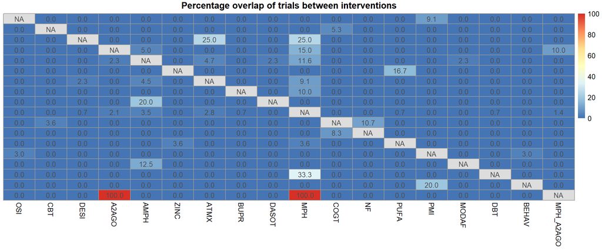

```r
filtered_matrix = readxl::read_excel("supplementary/datasets/matrix_cca.xlsx") %>% as.matrix()
# rownames(filtered_matrix) <- colnames(filtered_matrix)
pheatmap::pheatmap(
  filtered_matrix,
  display_numbers = TRUE,
  number_format = "%.1f",
  fontsize_number = 10,
  cluster_rows = FALSE,
  cluster_cols = FALSE,
  main = "Percentage overlap of trials between interventions"
)
```

```r
# PMI + BEHAV = Pfiffner_2014 (3 arms study)
# COGT + CBT = Virta_2010 (3 arms study)
# NF + CT = Hassingler (3 arms study)
# NF + CT = Steiner 2014 (3 arms study)
# PUFA + Zinc = Salehi 2016 (3 arms study)
#
# MIND + PMI = Valero 2022 (removed PMI)
# MIND + CBT = GU 2017 + Hepark 2015 (removed CBT)
#
# OSI + PMI = Abikoff 2013 (3 arms study)
# OSI + PMI = Sibley 2013 (removed PMI)
# PHYS + SST = Choi (2 different studies)
```

```r
df_cca = readxl::read_excel("supplementary/datasets/dataset_cca.xlsx")


df_cca %>%
  arrange(percent_of_A1_in_A2) %>%
  kbl() %>%
    kable_styling(bootstrap_options = c("striped", "hover", "condensed", "responsive"), position = "left") %>%
    scroll_box(width = "100%", height = "500px")
```

| Acronym_1 | Acronym_2 | num_shared_trials | Acronym_1_total_trials | Acronym_2_total_trials | percent_of_A1_in_A2 | percent_of_A2_in_A1 | shared_trial_IDs |
| --- | --- | --- | --- | --- | --- | --- | --- |
| MPH | PUFA | 1 | 141 | 28 | 0.7 | 3.6 | Barragan_2017 |
| MPH | DBT | 1 | 141 | 3 | 0.7 | 33.3 | Philipsen_2015 |
| MPH | MPH_A2AGO | 2 | 141 | 2 | 1.4 | 100.0 | Palumbo_2008, TSSG_2002 |
| AMPH | DASOT | 1 | 43 | 5 | 2.3 | 20.0 | Adler_2021 |
| AMPH | MODAF | 1 | 43 | 8 | 2.3 | 12.5 | Taylor_2000 |
| PMI | BEHAV | 1 | 33 | 5 | 3.0 | 20.0 | Pfiffner_2014 |
| AMPH | ATMX | 2 | 43 | 44 | 4.7 | 4.5 | Adler_2008, Kay_2009 |
| A2AGO | AMPH | 1 | 20 | 43 | 5.0 | 2.3 | Taylor_2001 |
| CBT | COGT | 1 | 19 | 28 | 5.3 | 3.6 | Virta_2010 |
| OSI | PMI | 1 | 11 | 33 | 9.1 | 3.0 | Sibley_2016 |
| ATMX | MPH | 4 | 44 | 141 | 9.1 | 2.8 | Adler_2009, Newcorn_2008, Spencer_2002, Weisler_2012 |
| A2AGO | MPH_A2AGO | 2 | 20 | 2 | 10.0 | 100.0 | Palumbo_2008, TSSG_2002 |
| BUPR | MPH | 1 | 10 | 141 | 10.0 | 0.7 | Kuperman_2001 |
| COGT | NF | 3 | 28 | 36 | 10.7 | 8.3 | Hasslinger_2021, Hasslinger_2022, Steiner_2014 |
| AMPH | MPH | 5 | 43 | 141 | 11.6 | 3.5 | Coghill_2013, Manos_1999, NCT01552902_NA, Plizka_2000, Ramtvedt_2013 |
| A2AGO | MPH | 3 | 20 | 141 | 15.0 | 2.1 | Kurlan_2002, Palumbo_2008, TSSG_2002 |
| ZINC | PUFA | 1 | 6 | 28 | 16.7 | 3.6 | Salehi_2016 |
| DESI | ATMX | 1 | 4 | 44 | 25.0 | 2.3 | Spencer_2002 |
| DESI | MPH | 1 | 4 | 141 | 25.0 | 0.7 | Spencer_2002 |

# S11. Primary outcomes

## General overview

At study endpoint

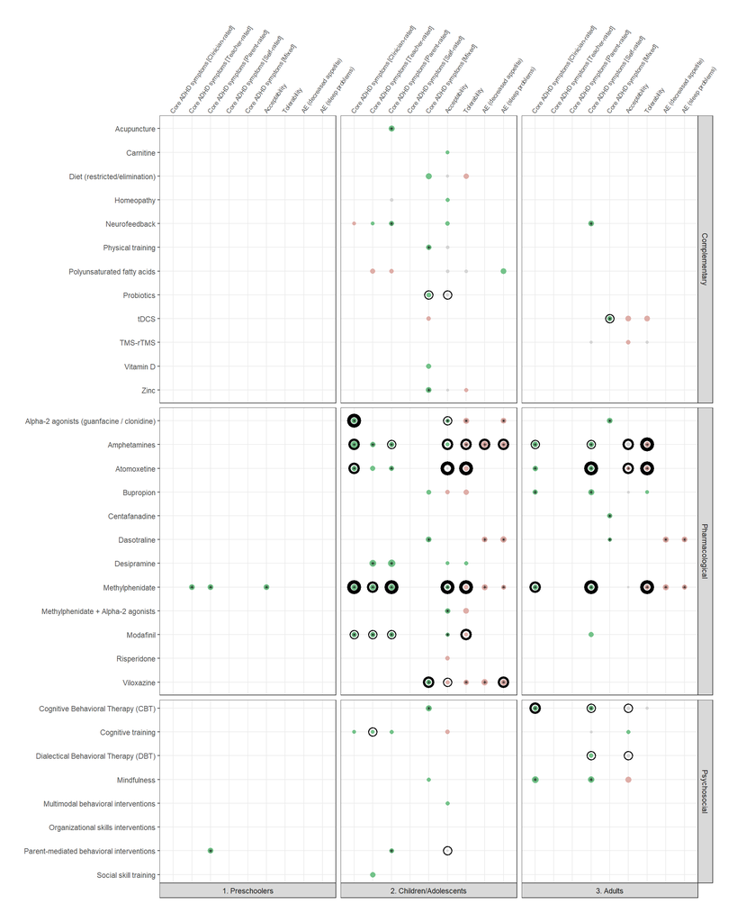

## Specific focus

### ADHD-Moderate/High evidence

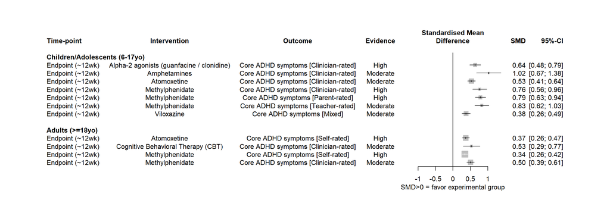

### Safety-Moderate/High evidence

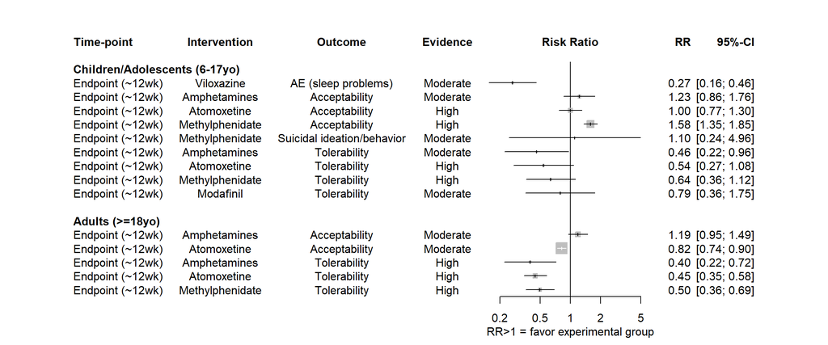

### Large efficacy

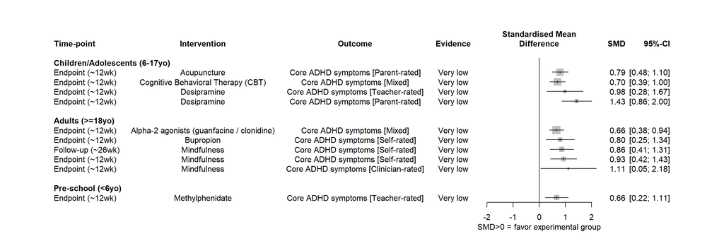

| meta_review | paper | Intervention | Age | Outcome | followup_rank | Raters | Class | measure | value | CI_95 | CI_lower | CI_upper | p_value | PI_95 | n_studies | total_n | egger_p | ESB_p | indirectness | report | rob | es | ci_lo | ci_up | Factor |
| --- | --- | --- | --- | --- | --- | --- | --- | --- | --- | --- | --- | --- | --- | --- | --- | --- | --- | --- | --- | --- | --- | --- | --- | --- | --- |
| 93 | Ang (2023) | Acupuncture | Children/Adolescents (6-17yo) | Generalized anxiety | Endpoint (~12wk) | Parent-rated | Low | G | 0.039 | [-0.258, 0.336] | -0.258 | 0.336 | 7.97e-01 | [-1.888, 1.966] | 2 | 171 | NaN | 6.10e-01 | no | 100.00000 | 100.000000 | 0.0390000 | -0.2580000 | 0.3360000 | Ang (2023)_Acupuncture_Generalized anxiety_Parent-rated_At study endpoint (closest to 12 weeks) |
| 93 | Ang (2023) | Acupuncture | Children/Adolescents (6-17yo) | Learning disorder symptoms | Endpoint (~12wk) | Parent-rated | Very low | G | 0.625 | [0.321, 0.93] | 0.321 | 0.930 | 5.72e-05 | [-1.349, 2.6] | 2 | 171 | NaN | 1.91e-01 | no | 100.00000 | 100.000000 | 0.6250000 | 0.3210000 | 0.9300000 | Ang (2023)_Acupuncture_Learning disorder symptoms_Parent-rated_At study endpoint (closest to 12 weeks) |
| 93 | Ang (2023) | Acupuncture | Children/Adolescents (6-17yo) | Conduct disorder symptoms (CD) | Endpoint (~12wk) | Parent-rated | Very low | G | 0.662 | [0.356, 0.968] | 0.356 | 0.968 | 2.17e-05 | [-1.319, 2.643] | 2 | 171 | NaN | 2.69e-01 | no | 100.00000 | 100.000000 | 0.6620000 | 0.3560000 | 0.9680000 | Ang (2023)_Acupuncture_Conduct Disorder symptoms_Parent-rated_At study endpoint (closest to 12 weeks) |
| 93 | Ang (2023) | Acupuncture | Children/Adolescents (6-17yo) | Core ADHD symptoms [Parent-rated] | Endpoint (~12wk) | Parent-rated | Very low | G | 0.793 | [0.484, 1.101] | 0.484 | 1.101 | 4.96e-07 | [-1.21, 2.795] | 2 | 171 | NaN | 3.67e-01 | no | 100.00000 | 100.000000 | 0.7930000 | 0.4840000 | 1.1010000 | Ang (2023)_Acupuncture_Combined ADHD symptoms (inattentive + hyperactive/impulsive)_Parent-rated_At study endpoint (closest to 12 weeks) |
| 757 | Cortese - Children (2018) | Alpha-2 agonists (guanfacine / clonidine) | Children/Adolescents (6-17yo) | Core ADHD symptoms [Clinician-rated] | Endpoint (~12wk) | Clinician-rated | High | G | 0.635 | [0.479, 0.79] | 0.479 | 0.790 | 1.19e-15 | [0.26, 1.01] | 8 | 1497 | 3.62e-01 | 2.31e-01 | no | 100.00000 | 86.860346 | 0.6350000 | 0.4790000 | 0.7900000 | Cortese - Children (2018)_Alpha-2 agonists (guanfacine / clonidine)_Combined ADHD symptoms (inattentive + hyperactive/impulsive)_Clinician-rated_At study endpoint (closest to 12 weeks) |
| 757 | Cortese - Children (2018) | Alpha-2 agonists (guanfacine / clonidine) | Children/Adolescents (6-17yo) | Acceptability | Endpoint (~12wk) | NA | Low | RR | 1.366 | [1.047, 1.781] | 1.047 | 1.781 | 2.13e-02 | [0.683, 2.73] | 11 | 1456 | 5.81e-01 | 6.05e-01 | no | 100.00000 | 84.343878 | 0.3118868 | 0.0459289 | 0.5771750 | Cortese - Children (2018)_Alpha-2 agonists (guanfacine / clonidine)_Acceptability: all-cause discontinuation_NA_At study endpoint (closest to 12 weeks) |
| 8992 | Fahrat (2024) | Alpha-2 agonists (guanfacine / clonidine) | Children/Adolescents (6-17yo) | Tics/Tourette disorder symptoms | Endpoint (~12wk) | N/A | Low | G | 0.771 | [0.524, 1.018] | 0.524 | 1.018 | 8.84e-10 | [0.371, 1.171] | 4 | 297 | 5.47e-01 | 1.64e-01 | no | 100.00000 | 100.000000 | 0.7710000 | 0.5240000 | 1.0180000 | Fahrat (2024)_Alpha-2 agonists (guanfacine / clonidine)_Tics/Tourette disorder symptoms_Mixed_At study endpoint (closest to 12 weeks) |
| 757 | Cortese - Children (2018) | Alpha-2 agonists (guanfacine / clonidine) | Children/Adolescents (6-17yo) | Tolerability | Endpoint (~12wk) | NA | Very low | RR | 0.281 | [0.125, 0.634] | 0.125 | 0.634 | 2.21e-03 | [0.056, 1.415] | 8 | 1287 | 4.30e-01 | 2.51e-03 | no | 100.00000 | 86.688965 | -1.2694006 | -2.0794415 | -0.4557063 | Cortese - Children (2018)_Alpha-2 agonists (guanfacine / clonidine)_Tolerability (discontinuation due to adverse events)_NA_At study endpoint (closest to 12 weeks) |
| 3090 | Ruggiero (2014) | Alpha-2 agonists (guanfacine / clonidine) | Children/Adolescents (6-17yo) | AE (sleep problems) | Endpoint (~12wk) | NA | Very low | RR | 0.300 | [0.169, 0.532] | 0.169 | 0.532 | 3.76e-05 | [0.051, 1.755] | 6 | 1704 | 6.08e-02 | 3.31e-04 | no | 79.62756 | 79.627557 | -1.2039728 | -1.7778566 | -0.6311118 | Ruggiero (2014)_Alpha-2 agonists (guanfacine / clonidine)_Specific adverse events: sleep problems_NA_At study endpoint (closest to 12 weeks) |
| 2902 | Radonjic (2023) | Alpha-2 agonists (guanfacine / clonidine) | Adults (>=18yo) | Core ADHD symptoms [Mixed] | Endpoint (~12wk) | Mixed | Very low | G | 0.660 | [0.382, 0.939] | 0.382 | 0.939 | 3.24e-06 | [-1.142, 2.463] | 2 | 235 | NaN | 7.86e-01 | no | 17.51211 | 17.512108 | 0.6600000 | 0.3820000 | 0.9390000 | Radonjic (2023)_Alpha-2 agonists (guanfacine / clonidine)_Combined ADHD symptoms (inattentive + hyperactive/impulsive)_Mixed_At study endpoint (closest to 12 weeks) |
| 2877 | Punja (2016) | Amphetamines | Children/Adolescents (6-17yo) | AE (decreased appetite) | Endpoint (~12wk) | NA | Low | RR | 0.185 | [0.104, 0.329] | 0.104 | 0.329 | 1.02e-08 | [0.037, 0.927] | 11 | 2467 | 6.26e-03 | 2.73e-01 | no | 70.80113 | 70.801135 | -1.6873995 | -2.2633644 | -1.1116975 | Punja (2016)_Amphetamine_Specific adverse events: decreased appetite_NA_At study endpoint (closest to 12 weeks) |
| 2877 | Punja (2016) | Amphetamines | Children/Adolescents (6-17yo) | AE (sleep problems) | Endpoint (~12wk) | NA | Low | RR | 0.281 | [0.174, 0.456] | 0.174 | 0.456 | 2.52e-07 | [0.088, 0.898] | 10 | 2429 | 9.06e-02 | 4.69e-01 | no | 67.30355 | 67.303548 | -1.2694006 | -1.7487000 | -0.7852625 | Punja (2016)_Amphetamine_Specific adverse events: sleep problems_NA_At study endpoint (closest to 12 weeks) |
| 757 | Cortese - Children (2018) | Amphetamines | Children/Adolescents (6-17yo) | Tolerability | Endpoint (~12wk) | NA | Moderate | RR | 0.463 | [0.223, 0.959] | 0.223 | 0.959 | 3.83e-02 | [0.174, 1.228] | 7 | 1343 | 1.84e-01 | 4.34e-01 | no | 100.00000 | 100.000000 | -0.7700282 | -1.5005835 | -0.0418642 | Cortese - Children (2018)_Amphetamine_Tolerability (discontinuation due to adverse events)_NA_At study endpoint (closest to 12 weeks) |
| 757 | Cortese - Children (2018) | Amphetamines | Children/Adolescents (6-17yo) | Acceptability | Endpoint (~12wk) | NA | Moderate | RR | 1.227 | [0.858, 1.756] | 0.858 | 1.756 | 2.63e-01 | [0.486, 3.1] | 7 | 1343 | 1.12e-01 | 4.74e-01 | no | 100.00000 | 100.000000 | 0.2045722 | -0.1531512 | 0.5630385 | Cortese - Children (2018)_Amphetamine_Acceptability: all-cause discontinuation_NA_At study endpoint (closest to 12 weeks) |
| 2877 | Punja (2016) | Amphetamines | Children/Adolescents (6-17yo) | Academic/job performance | Endpoint (~12wk) | NA | Moderate | G | 0.551 | [0.374, 0.728] | 0.374 | 0.728 | 1.02e-09 | [0.149, 0.952] | 8 | 826 | 3.52e-02 | 9.07e-01 | no | 100.00000 | 100.000000 | 0.5510000 | 0.3740000 | 0.7280000 | Punja (2016)_Amphetamine_Academic/job performance_NA_At study endpoint (closest to 12 weeks) |
| 757 | Cortese - Children (2018) | Amphetamines | Children/Adolescents (6-17yo) | Core ADHD symptoms [Clinician-rated] | Endpoint (~12wk) | Clinician-rated | Moderate | G | 1.024 | [0.672, 1.376] | 0.672 | 1.376 | 1.17e-08 | [-0.078, 2.126] | 5 | 876 | 5.11e-01 | 3.55e-01 | no | 100.00000 | 100.000000 | 1.0240000 | 0.6720000 | 1.3760000 | Cortese - Children (2018)_Amphetamine_Combined ADHD symptoms (inattentive + hyperactive/impulsive)_Clinician-rated_At study endpoint (closest to 12 weeks) |
| 2877 | Punja (2016) | Amphetamines | Children/Adolescents (6-17yo) | Core ADHD symptoms [Parent-rated] | Endpoint (~12wk) | Parent-rated | Low | G | 0.568 | [0.28, 0.855] | 0.280 | 0.855 | 1.07e-04 | [-0.288, 1.423] | 7 | 1247 | 6.63e-01 | 5.71e-01 | no | 82.65086 | 82.650857 | 0.5680000 | 0.2800000 | 0.8550000 | Punja (2016)_Amphetamine_Combined ADHD symptoms (inattentive + hyperactive/impulsive)_Parent-rated_At study endpoint (closest to 12 weeks) |
| 8888 | Bellatto - children (2024) | Amphetamines | Children/Adolescents (6-17yo) | Quality of life | Endpoint (~12wk) | Self-rated | Very low | G | 0.475 | [-0.523, 1.474] | -0.523 | 1.474 | 3.51e-01 | [-10.598, 11.548] | 2 | 521 | NaN | 6.16e-01 | no | 100.00000 | 100.000000 | 0.4750000 | -0.5230000 | 1.4740000 | Bellatto - children (2024)_Amphetamine_Quality of life (patients)_Self-rated_At study endpoint (closest to 12 weeks) |
| 2877 | Punja (2016) | Amphetamines | Children/Adolescents (6-17yo) | Core ADHD symptoms [Teacher-rated] | Endpoint (~12wk) | Teacher-rated | Very low | G | 0.553 | [0.274, 0.833] | 0.274 | 0.833 | 1.04e-04 | [-0.141, 1.248] | 5 | 745 | 4.38e-01 | 2.25e-01 | no | 100.00000 | 100.000000 | 0.5530000 | 0.2740000 | 0.8330000 | Punja (2016)_Amphetamine_Combined ADHD symptoms (inattentive + hyperactive/impulsive)_Teacher-rated_At study endpoint (closest to 12 weeks) |
| 2877 | Punja (2016) | Amphetamines | Children/Adolescents (6-17yo) | CGI | Endpoint (~12wk) | N/A | Very low | G | 0.873 | [0.012, 1.733] | 0.012 | 1.733 | 4.69e-02 | [-7.752, 9.497] | 2 | 86 | NaN | 5.90e-01 | no | 100.00000 | 100.000000 | 0.8730000 | 0.0120000 | 1.7330000 | Punja (2016)_Amphetamine_CGI_Mixed_At study endpoint (closest to 12 weeks) |
| 1110 | Faraone (2002) | Amphetamines | Children/Adolescents (6-17yo) | Disruptive behaviors | Endpoint (~12wk) | N/A | Very low | G | 1.049 | [0.645, 1.453] | 0.645 | 1.453 | 3.70e-07 | [-0.156, 2.254] | 3 | 130 | 3.34e-01 | 9.24e-01 | no | 0.00000 | 0.000000 | 1.0490000 | 0.6450000 | 1.4530000 | Faraone (2002)_Amphetamine_Disruptive behaviors_Mixed_At study endpoint (closest to 12 weeks) |
| 999 | Ostinelli (2025) | Amphetamines | Adults (>=18yo) | Tolerability | Endpoint (~12wk) | NA | High | RR | 0.398 | [0.22, 0.718] | 0.220 | 0.718 | 2.24e-03 | [0.203, 0.779] | 11 | 1995 | 8.58e-01 | 9.17e-01 | no | 96.43121 | 96.431215 | -0.9213033 | -1.5141277 | -0.3312857 | Ostinelli (2025)_Amphetamine_Tolerability (discontinuation due to adverse events)_NA_At study endpoint (closest to 12 weeks) |
| 999 | Ostinelli (2025) | Amphetamines | Adults (>=18yo) | Acceptability | Endpoint (~12wk) | NA | Moderate | RR | 1.189 | [0.951, 1.485] | 0.951 | 1.485 | 1.29e-01 | [0.747, 1.89] | 10 | 1957 | 6.07e-01 | 6.42e-01 | no | 100.00000 | 100.000000 | 0.1731126 | -0.0502412 | 0.3954148 | Ostinelli (2025)_Amphetamine_Acceptability: all-cause discontinuation_NA_At study endpoint (closest to 12 weeks) |
| 999 | Ostinelli (2025) | Amphetamines | Adults (>=18yo) | Core ADHD symptoms [Self-rated] | Endpoint (~12wk) | Self-rated | Low | G | 0.534 | [0.297, 0.77] | 0.297 | 0.770 | 9.58e-06 | [0.15, 0.917] | 4 | 300 | 5.04e-01 | 5.60e-01 | no | 100.00000 | 100.000000 | 0.5340000 | 0.2970000 | 0.7700000 | Ostinelli (2025)_Amphetamine_Combined ADHD symptoms (inattentive + hyperactive/impulsive)_Self-rated_At study endpoint (closest to 12 weeks) |
| 999 | Ostinelli (2025) | Amphetamines | Adults (>=18yo) | Core ADHD symptoms [Clinician-rated] | Endpoint (~12wk) | Clinician-rated | Low | G | 0.631 | [0.395, 0.868] | 0.395 | 0.868 | 1.71e-07 | [-0.113, 1.376] | 9 | 1857 | 3.14e-01 | 3.76e-01 | no | 86.61902 | 86.619020 | 0.6310000 | 0.3950000 | 0.8680000 | Ostinelli (2025)_Amphetamine_Combined ADHD symptoms (inattentive + hyperactive/impulsive)_Clinician-rated_At study endpoint (closest to 12 weeks) |
| 563 | Castells (2018) | Amphetamines | Adults (>=18yo) | Depressive disorder symptoms | Endpoint (~12wk) | Clinician-rated | Very low | G | -0.157 | [-0.523, 0.209] | -0.523 | 0.209 | 4.00e-01 | [-2.529, 2.215] | 2 | 110 | NaN | 6.68e-01 | no | 100.00000 | 100.000000 | -0.1570000 | -0.5230000 | 0.2090000 | Castells (2018)_Amphetamine_Depressive disorder symptoms_Clinician-rated_At study endpoint (closest to 12 weeks) |
| 563 | Castells (2018) | Amphetamines | Adults (>=18yo) | Generalized anxiety | Endpoint (~12wk) | Clinician-rated | Very low | G | -0.130 | [-0.495, 0.236] | -0.495 | 0.236 | 4.88e-01 | [-2.502, 2.243] | 2 | 110 | NaN | 6.52e-01 | no | 100.00000 | 100.000000 | -0.1300000 | -0.4950000 | 0.2360000 | Castells (2018)_Amphetamine_Generalized anxiety_Clinician-rated_At study endpoint (closest to 12 weeks) |
| 2027 | Lenzi (2018) | Amphetamines | Adults (>=18yo) | Emotional dysregulation | Endpoint (~12wk) | N/A | Very low | G | 0.344 | [0.121, 0.567] | 0.121 | 0.567 | 2.54e-03 | [-0.407, 1.095] | 3 | 235 | 1.18e-01 | 9.93e-02 | no | 100.00000 | 100.000000 | 0.3440000 | 0.1210000 | 0.5670000 | Lenzi (2018)_Amphetamine_Emotional dysregulation_Mixed_At study endpoint (closest to 12 weeks) |
| 8888 | Bellato - adults (2024) | Amphetamines | Adults (>=18yo) | Quality of life | Endpoint (~12wk) | Self-rated | Very low | G | 0.524 | [0.325, 0.723] | 0.325 | 0.723 | 2.51e-07 | [-1.02, 2.067] | 2 | 429 | NaN | 3.55e-01 | no | 100.00000 | 100.000000 | 0.5240000 | 0.3250000 | 0.7230000 | Bellato - adults (2024)_Amphetamine_Quality of life (patients)_Self-rated_At study endpoint (closest to 12 weeks) |
| 1056 | Elliott (2020) | Amphetamines | Adults (>=18yo) | Exec. functions (report) | Endpoint (~12wk) | N/A | Very low | G | 0.655 | [0.507, 0.804] | 0.507 | 0.804 | 5.79e-18 | [0.414, 0.897] | 4 | 722 | 8.13e-01 | 3.86e-01 | no | 0.00000 | 0.000000 | 0.6550000 | 0.5070000 | 0.8040000 | Elliott (2020)_Amphetamine_Executive functioning (report)_Mixed_At study endpoint (closest to 12 weeks) |

[output cut: 191 more lines]

# S12. Secondary outcomes

## General overview

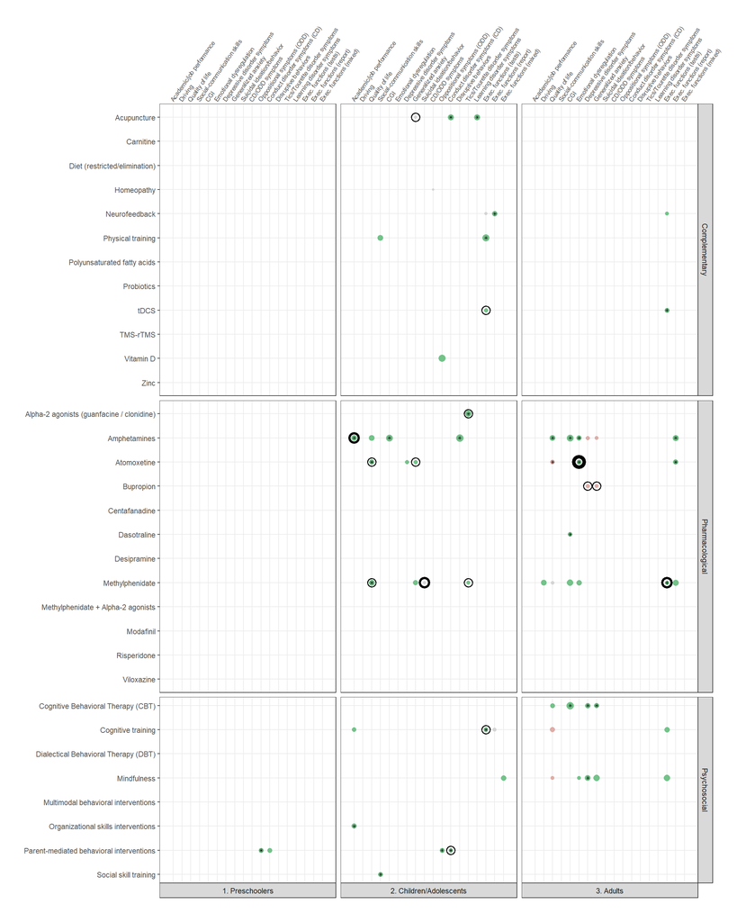

## Specific focus

### Moderate/High evidence

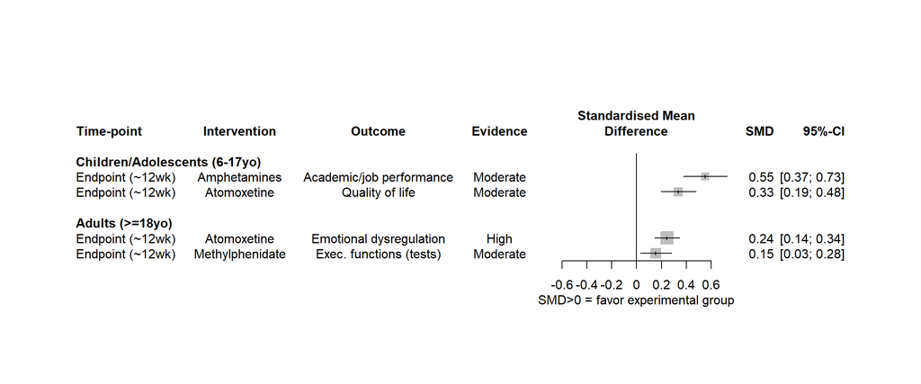

### Large efficacy

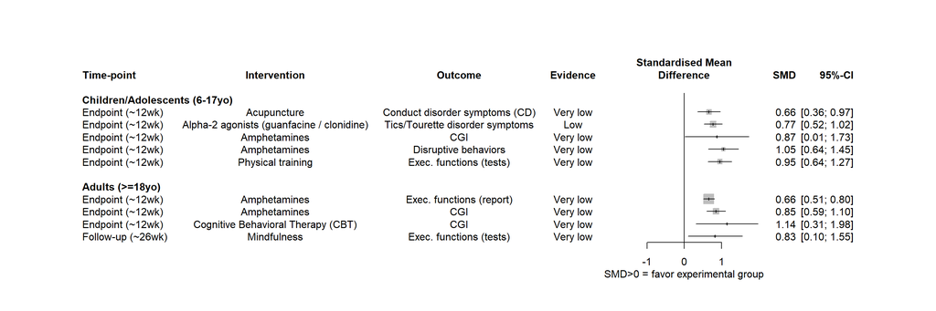

# S13. Longer-term

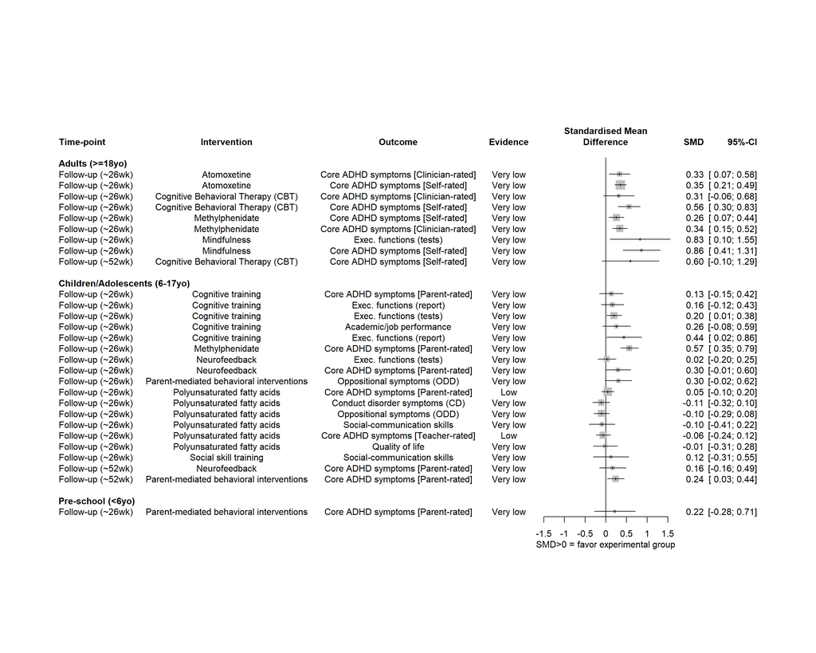

# S14. Sensitivity: Low RoB

| Age_simp | Factor | GRADE_simp | GRADE_bias | p_value_simp | p_value_bias | measure_simp | es_bias | es_simp |
| --- | --- | --- | --- | --- | --- | --- | --- | --- |
| Children/Adolescents (6-17yo) | Punja (2016)_Amphetamine_Specific adverse events: decreased appetite_NA_At study endpoint (closest to 12 weeks) | Low | High | 1.02e-08 | 3.68e-10 | RR | -1.8773174 | -1.6873995 |
| Children/Adolescents (6-17yo) | Punja (2016)_Amphetamine_Specific adverse events: sleep problems_NA_At study endpoint (closest to 12 weeks) | Low | High | 2.52e-07 | 3.66e-06 | RR | -1.2658482 | -1.2694006 |
| Children/Adolescents (6-17yo) | Punja (2016)_Amphetamine_Combined ADHD symptoms (inattentive + hyperactive/impulsive)_Parent-rated_At study endpoint (closest to 12 weeks) | Low | Moderate | 1.07e-04 | 1.25e-09 | G | 0.3980000 | 0.5680000 |
| Adults (>=18yo) | Ostinelli (2025)_Amphetamine_Combined ADHD symptoms (inattentive + hyperactive/impulsive)_Clinician-rated_At study endpoint (closest to 12 weeks) | Low | High | 1.71e-07 | 5.33e-10 | G | 0.7010000 | 0.6310000 |
| Children/Adolescents (6-17yo) | Westwood - Children (2024)_Cognitive training_Executive functioning (tests)_NA_At study endpoint (closest to 12 weeks) | Low | Moderate | 5.27e-03 | 1.02e-01 | G | 0.1610000 | 0.1990000 |
| Children/Adolescents (6-17yo) | Gillies (2023)_Polyunsaturated fatty acids_Combined ADHD symptoms (inattentive + hyperactive/impulsive)_Teacher-rated_At follow-up (closest to 26 weeks) | Low | Moderate | 5.11e-01 | 6.67e-01 | G | -0.0530000 | -0.0610000 |
| Children/Adolescents (6-17yo) | Storebo (2023)_Methylphenidate_Suicidal ideation/behavior_Mixed_At study endpoint (closest to 12 weeks) | Moderate | Weak | 8.98e-01 | 7.57e-01 | RR | 0.2700271 | 0.0980337 |
| Adults (>=18yo) | Pievsky (2018)_Methylphenidate_Executive functioning (tests)_Clinician-rated_At study endpoint (closest to 12 weeks) | Moderate | Weak | 1.62e-02 | 3.16e-02 | G | 0.1470000 | 0.1540000 |
| Children/Adolescents (6-17yo) | Westwood - Children (2024)_Cognitive training_Combined ADHD symptoms (inattentive + hyperactive/impulsive)_Parent-rated_At study endpoint (closest to 12 weeks) | Very low | Moderate | 9.61e-02 | 8.11e-01 | G | 0.0350000 | 0.1980000 |
| Adults (>=18yo) | Boesen (2022)_Methylphenidate_Specific adverse events: decreased appetite_NA_At study endpoint (closest to 12 weeks) | Very low | Moderate | 5.06e-43 | 1.17e-11 | RR | -1.5324769 | -1.4064971 |
| Children/Adolescents (6-17yo) | Westwood - Children (2025)_Neurofeedback_Executive functioning (tests)_NA_At study endpoint (closest to 12 weeks) | Very low | Moderate | 4.74e-01 | 6.91e-01 | G | 0.0650000 | 0.0430000 |